# Simulations in R Part 8 - Simulating Mixed Models

Patrick Ward

11/2/2023

## Introduction

We’ve built up a number of simmulations over the 7 articles in this series. The last few articles have been looking at linear regression and simulating different intricacies in the data that allow us to explore model assumptions. To end this series, we will now extend the linear model to a mixed model. We will start by building a linear regression model and go through the steps of simulation to build up the hierarchical structure of the data.

```r
library(tidyverse)
library(broom)
library(lme4)
theme_set(theme_light())
```

## First a linear model

Our data will look at training load for 10 players in two different positions, Forwards (F) and Mids (M). The Forwards will be simulated to have less training load than the Mids and we will add some random error around the difference in these group means. We will simulate this as a linaer model where b0 represents the model intercept and is the mean value for Forwards and b1 represents the coefficient for when the group is Mids.

```r
## Model Parameters
n_positions <- 2
n_players <- 10
b0 <- 80
b1 <- 20
sigma <- 10

## Simulate
set.seed(300)
pos <- rep(c("M", "F"), each = n_players)
player_id <- rep(1:10, times = 2)
model_error <- rnorm(n = n_positions*n_players, mean = 0, sd = sigma)
training_load <- b0 + b1 * (pos == "M") + model_error

d <- data.frame(pos, player_id, training_load)
d
```

```
##    pos player_id training_load
## 1    M         1     113.73791
## 2    M         2     108.62107
## 3    M         3     104.73489
## 4    M         4     107.01263
## 5    M         5      99.14945
## 6    M         6     115.68702
## 7    M         7     108.17392
## 8    M         8     103.94769
## 9    M         9     112.12699
## 10   M        10     103.55081
## 11   F         1     102.16274
## 12   F         2      79.09460
## 13   F         3      66.83472
## 14   F         4      80.66535
## 15   F         5      85.12173
## 16   F         6      80.50030
## 17   F         7      94.67397
## 18   F         8      67.10479
## 19   F         9      77.42308
## 20   F        10      82.93051
```

**Summary Statistics**

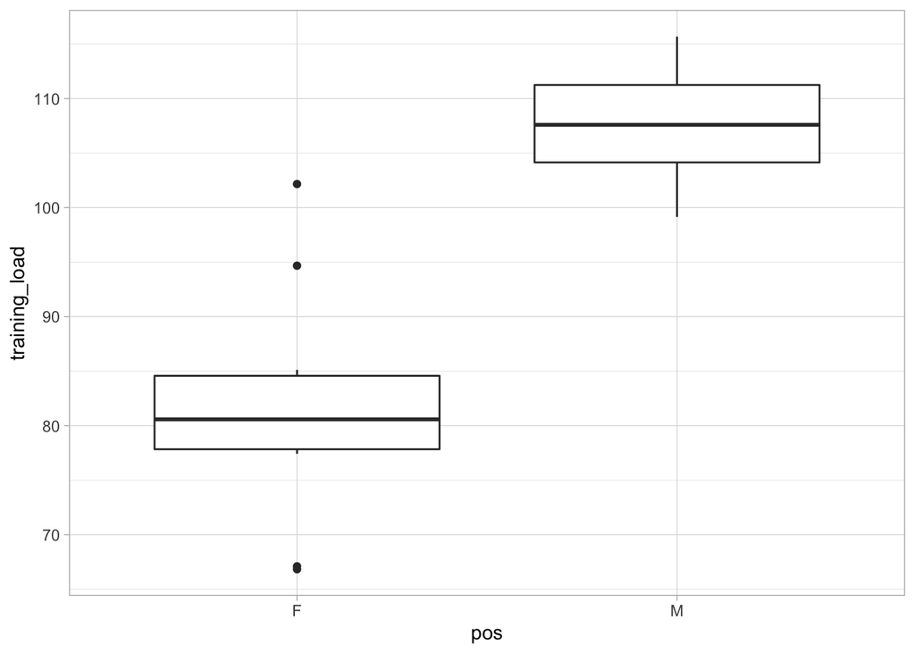

```r
d %>%
  ggplot(aes(x = pos, y = training_load)) +
  geom_boxplot()
```

```r
d %>%
  group_by(pos) %>%
  summarize(N = n(),
            avg = mean(training_load),
            sd = sd(training_load)) %>%
  mutate(se = sd / sqrt(N)) %>%
  knitr::kable()
```

| pos | N | avg | sd | se |
| --- | --- | --- | --- | --- |
| F | 10 | 81.65118 | 10.861925 | 3.434842 |
| M | 10 | 107.67424 | 5.105393 | 1.614467 |

**Build a linear model**

```r
fit <- lm(training_load ~ pos, data = d)
summary(fit)
```

```
##
## Call:
## lm(formula = training_load ~ pos, data = d)
##
## Residuals:
##      Min       1Q   Median       3Q      Max
## -14.8165  -3.8258  -0.8237   3.7161  20.5116
##
## Coefficients:
##             Estimate Std. Error t value Pr(>|t|)
## (Intercept)   81.651      2.684  30.425  < 2e-16 ***
## posM          26.023      3.795   6.857 2.05e-06 ***
## ---
## Signif. codes:  0 '***' 0.001 '**' 0.01 '*' 0.05 '.' 0.1 ' ' 1
##
## Residual standard error: 8.487 on 18 degrees of freedom
## Multiple R-squared:  0.7231, Adjusted R-squared:  0.7077
## F-statistic: 47.01 on 1 and 18 DF,  p-value: 2.047e-06
```

Wrap all the steps in a function so that we can use `replicate()` to create thousands of simulations or to change parameters of our simulation. The end result of the function is going to be the linear regression model.

```r
sim_func <- function(n_positions = 2, n_players = 10, b0 = 80, b1 = 20, sigma = 10){

  ## simulate data
  pos <- rep(c("M", "F"), each = n_players)
  player_id <- rep(1:10, times = 2)
  model_error <- rnorm(n = n_positions*n_players, mean = 0, sd = sigma)
  training_load <- b0 + b1 * (pos == "M") + model_error

  ## store in data frame
  d <- data.frame(pos, player_id, training_load)

  ## construct linear model
  fit <- lm(training_load ~ pos, data = d)
  summary(fit)
}
```

**Try the function out with the default parameters**

```r
sim_func()
```

```
##
## Call:
## lm(formula = training_load ~ pos, data = d)
##
## Residuals:
##     Min      1Q  Median      3Q     Max
## -12.620  -4.365  -0.004   5.178  12.214
##
## Coefficients:
##             Estimate Std. Error t value Pr(>|t|)
## (Intercept)   78.134      2.111  37.011  < 2e-16 ***
## posM          23.038      2.986   7.717 4.08e-07 ***
## ---
## Signif. codes:  0 '***' 0.001 '**' 0.01 '*' 0.05 '.' 0.1 ' ' 1
##
## Residual standard error: 6.676 on 18 degrees of freedom
## Multiple R-squared:  0.7679, Adjusted R-squared:  0.755
## F-statistic: 59.55 on 1 and 18 DF,  p-value: 4.081e-07
```

Notice what happens to the model if we change our b1 coefficient.

```r
sim_func(b1 = 40)
```

```
##
## Call:
## lm(formula = training_load ~ pos, data = d)
##
## Residuals:
##      Min       1Q   Median       3Q      Max
## -14.3722  -6.1892   0.8445   3.8213  17.5655
##
## Coefficients:
##             Estimate Std. Error t value Pr(>|t|)
## (Intercept)   79.113      2.586   30.59  < 2e-16 ***
## posM          46.197      3.657   12.63  2.2e-10 ***
## ---
## Signif. codes:  0 '***' 0.001 '**' 0.01 '*' 0.05 '.' 0.1 ' ' 1
##
## Residual standard error: 8.178 on 18 degrees of freedom
## Multiple R-squared:  0.8986, Adjusted R-squared:  0.893
## F-statistic: 159.6 on 1 and 18 DF,  p-value: 2.199e-10
```

**Use `replicate()` to create many simulations.**

Doing this simulation once doesn’t help us. We want to be able to do this thousands of times. All of the articles in this series have used `for()` loops up until this point. But, if you recall the first article in the series where I laid out several helpful functions for coding simulations, I showed an example of the `replicate()` function, which will take a function and run it’s result for as many times as you specify. I found this function while I was working through Gelman et al’s book, Regression and Other Stories. I think in cases like a mixed model simulation, where you can have many layers and complexities to the data, writing a simple function and then replicating it thousands of times is much easier to debug and much cleaner for others to read than having a bunch of nested `for()` loops.

*Technical Note:* We specify the argument `simplfy = FALSE` so that the results are returned in a list format. This makes more sense since the results are the regression summary results and not a data frame.

```r
team_training <- replicate(n = 1000,
                  sim_func(),
                  simplify = FALSE)
```

Coefficient Results

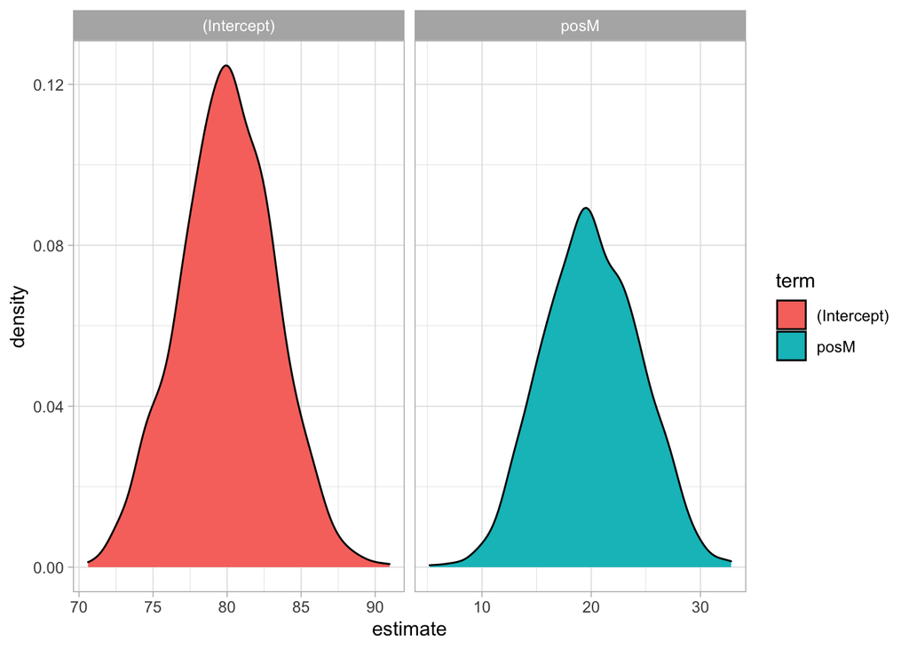

```r
team_training %>%
  map_df(tidy) %>%
  select(term, estimate) %>%
  ggplot(aes(x = estimate, fill = term)) +
  geom_density() +
  facet_wrap(~term, scales = "free_x")
```

```r
team_training %>%
  map_df(tidy) %>%
  select(term, estimate) %>%
  group_by(term) %>%
  summarize(avg = mean(estimate),
            SD = sd(estimate))
```

```
## # A tibble: 2 × 3
##   term          avg    SD
##   <chr>       <dbl> <dbl>
## 1 (Intercept)  80.0  3.21
## 2 posM         20.0  4.37
```

Compare the simulated results to the results of the original model fit.

```r
tidy(fit)
```

```
## # A tibble: 2 × 5
##   term        estimate std.error statistic  p.value
##   <chr>          <dbl>     <dbl>     <dbl>    <dbl>
## 1 (Intercept)     81.7      2.68     30.4  6.25e-17
## 2 posM            26.0      3.80      6.86 2.05e- 6
```

Model fit parameters

```r
team_training %>%
  map_df(glance) %>%
  select(adj.r.squared, sigma) %>%
  summarize(across(.cols = everything(),
                   ~mean(.x)))
```

```
## # A tibble: 1 × 2
##   adj.r.squared sigma
##           <dbl> <dbl>
## 1         0.500  9.88
```

Compare with original fit

```r
fit %>%
  glance()
```

```
## # A tibble: 1 × 12
##   r.squared adj.r.squared sigma statistic    p.value    df logLik   AIC   BIC
##       <dbl>         <dbl> <dbl>     <dbl>      <dbl> <dbl>  <dbl> <dbl> <dbl>
## 1     0.723         0.708  8.49      47.0 0.00000205     1  -70.1  146.  149.
## # … with 3 more variables: deviance <dbl>, df.residual <int>, nobs <int>
```

## Mixed Model 1

Now that we have the general frame work for building a simulation function and using `replicate()` we will to build a mixed model simulation.

Above we had a team with two positions groups and individual players nested within those position groups. In this mixed model, we will add a second team so that we can explore hierarchical data.

```r
## Model Parameters
n_teams <- 2
n_positions <- 2
n_players <- 10
intercept <- 80
pos_coef <- 20
team_coef <- 50
sigma_team1 <- 10
sigma_team2 <- 15

## Simulated data frame
team <- rep(c("Team1","Team2"), each = n_players * n_positions)
pos <- c(rep(c("M", "F"), each = n_players), rep(c("M", "F"), each = n_players))
player_id <- as.factor(round(seq(from = 100, to = 200, length = length(team)), 0))

set.seed(444)
model_error <- c(rnorm(n = length(team == "Team1"), mean = 0, sd = sigma_team1),
                 rnorm(n = length(team == "Team2"), mean = 0, sd = sigma_team2))
training_load <- intercept + pos_coef * (pos == "M") + team_coef * (team == "Team2") + model_error

d <- data.frame(team, pos, player_id, training_load)
d %>%
  head()
```

```
##    team pos player_id training_load
## 1 Team1   M       100      90.38113
## 2 Team1   M       103      97.19863
## 3 Team1   M       105      83.44124
## 4 Team1   M       108     101.49544
## 5 Team1   M       110     110.32413
## 6 Team1   M       113      94.87948
```

```r
fit_lmer <- lmer(training_load ~ pos + (1 |team), data = d)
summary(fit_lmer)
```

```
## Linear mixed model fit by REML ['lmerMod']
## Formula: training_load ~ pos + (1 | team)
##    Data: d
##
## REML criterion at convergence: 637.3
##
## Scaled residuals:
##     Min      1Q  Median      3Q     Max
## -1.7829 -0.7044 -0.1788  0.5953  2.4920
##
## Random effects:
##  Groups   Name        Variance Std.Dev.
##  team     (Intercept) 1249.1   35.34
##  Residual              175.2   13.24
## Number of obs: 80, groups:  team, 2
##
## Fixed effects:
##             Estimate Std. Error t value
## (Intercept)   106.31      25.08   4.239
## posM           15.31       2.96   5.171
##
## Correlation of Fixed Effects:
##      (Intr)
## posM -0.059
```

```r
coef(fit_lmer)
```

```
## $team
##       (Intercept)     posM
## Team1    81.36794 15.30662
## Team2   131.26300 15.30662
##
## attr(,"class")
## [1] "coef.mer"
```

```r
fixef(fit_lmer)
```

```
## (Intercept)        posM
##   106.31547    15.30662
```

```r
ranef(fit_lmer)
```

```
## $team
##       (Intercept)
## Team1   -24.94753
## Team2    24.94753
##
## with conditional variances for "team"
```

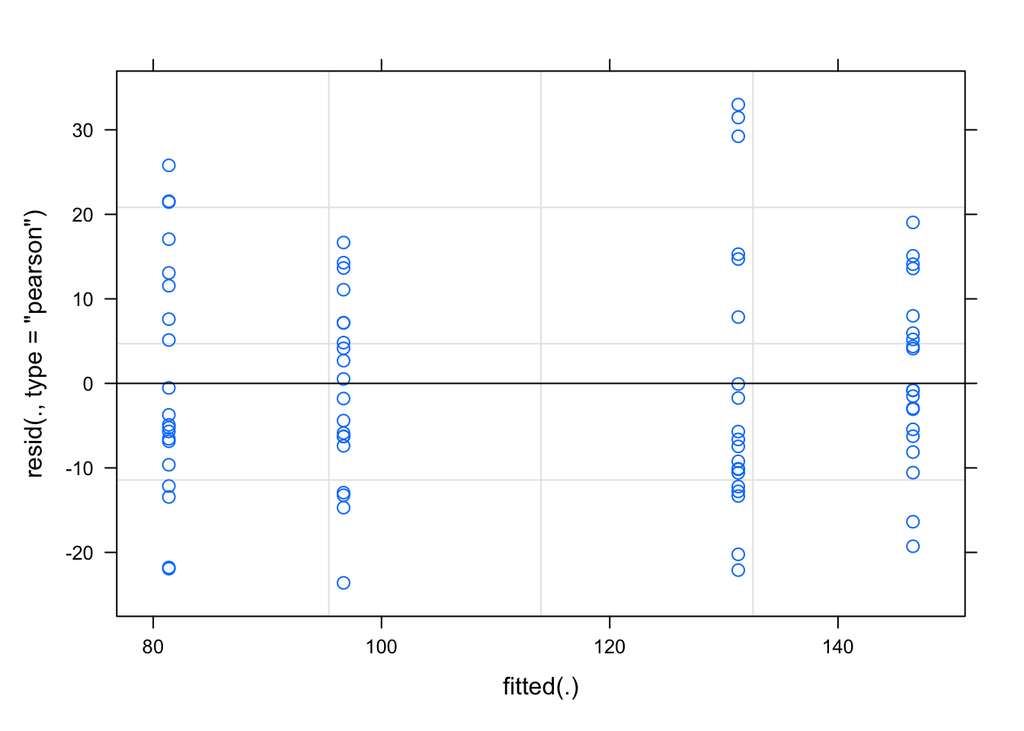

```r
plot(fit_lmer)
```

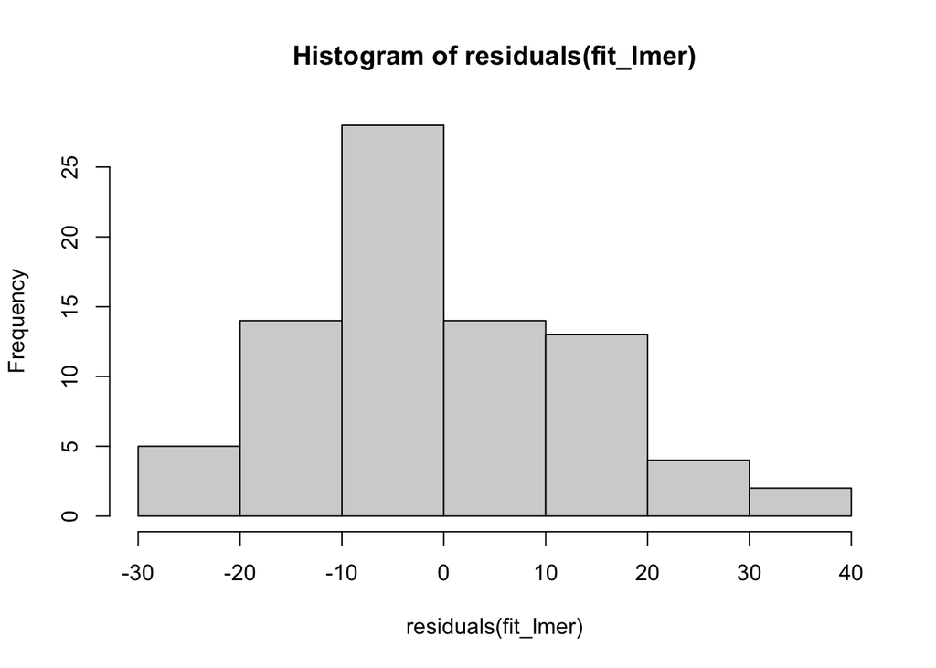

```r
hist(residuals(fit_lmer))
```

```r
sigma(fit_lmer)
```

```
## [1] 13.23792
```

```r
## Model Parameters
n_teams <- 3
n_positions <- 2
n_players <- 10

team1_fwd_avg <- 130
team1_fwd_sd <- 15
team1_mid_avg <- 100
team1_mid_sd <- 5

team2_fwd_avg <- 150
team2_fwd_sd <- 20
team2_mid_avg <- 90
team2_mid_sd <- 10

team3_fwd_avg <- 180
team3_fwd_sd <- 15
team3_mid_avg <- 150
team3_mid_sd <- 15


## Simulated data frame
team <- rep(c("Team1","Team2", "Team3"), each = n_players * n_positions)
pos <- c(rep(c("M", "F"), each = n_players), rep(c("M", "F"), each = n_players), rep(c("M", "F"), each = n_players))
player_id <- as.factor(round(seq(from = 100, to = 300, length = length(team)), 0))

d <- data.frame(team, pos, player_id)

d %>%
  head()
```

```
##    team pos player_id
## 1 Team1   M       100
## 2 Team1   M       103
## 3 Team1   M       107
## 4 Team1   M       110
## 5 Team1   M       114
## 6 Team1   M       117
```

```r
# simulate training loads
set.seed(555)
training_load <- c(rnorm(n = n_players, mean = team1_mid_avg, sd = team1_mid_sd),
                   rnorm(n = n_players, mean = team1_fwd_avg, sd = team1_fwd_sd),
                   rnorm(n = n_players, mean = team2_mid_avg, sd = team2_mid_sd),
                   rnorm(n = n_players, mean = team2_fwd_avg, sd = team2_fwd_sd),
                   rnorm(n = n_players, mean = team3_mid_avg, sd = team3_mid_sd),
                   rnorm(n = n_players, mean = team3_fwd_avg, sd = team3_fwd_sd))

d <- d %>%
  bind_cols(training_load = training_load)

d %>%
  head()
```

```
##    team pos player_id training_load
## 1 Team1   M       100      98.35070
## 2 Team1   M       103     102.51823
## 3 Team1   M       107     101.87185
## 4 Team1   M       110     109.44310
## 5 Team1   M       114      91.10049
## 6 Team1   M       117     104.42816
```

Calculate summary statistics

```r
## Average training load by team
d %>%
  group_by(team) %>%
  summarize(avg = mean(training_load),
            SD = sd(training_load))
```

```
## # A tibble: 3 × 3
##   team    avg    SD
##   <chr> <dbl> <dbl>
## 1 Team1  112.  12.8
## 2 Team2  119.  28.9
## 3 Team3  167.  22.4
```

```r
## Average training load by pos
d %>%
  group_by(pos) %>%
  summarize(avg = mean(training_load),
            SD = sd(training_load))
```

```
## # A tibble: 2 × 3
##   pos     avg    SD
##   <chr> <dbl> <dbl>
## 1 F      149.  25.6
## 2 M      116.  31.3
```

```r
## Average training load by team & position
d %>%
  group_by(team, pos) %>%
  summarize(avg = mean(training_load),
            SD = sd(training_load)) %>%
  arrange(pos)
```

```
## # A tibble: 6 × 4
## # Groups:   team [3]
##   team  pos     avg    SD
##   <chr> <chr> <dbl> <dbl>
## 1 Team1 F     123.   8.97
## 2 Team2 F     146.   8.89
## 3 Team3 F     179.  11.5
## 4 Team1 M     102.   5.04
## 5 Team2 M      92.1  8.78
## 6 Team3 M     154.  24.1
```

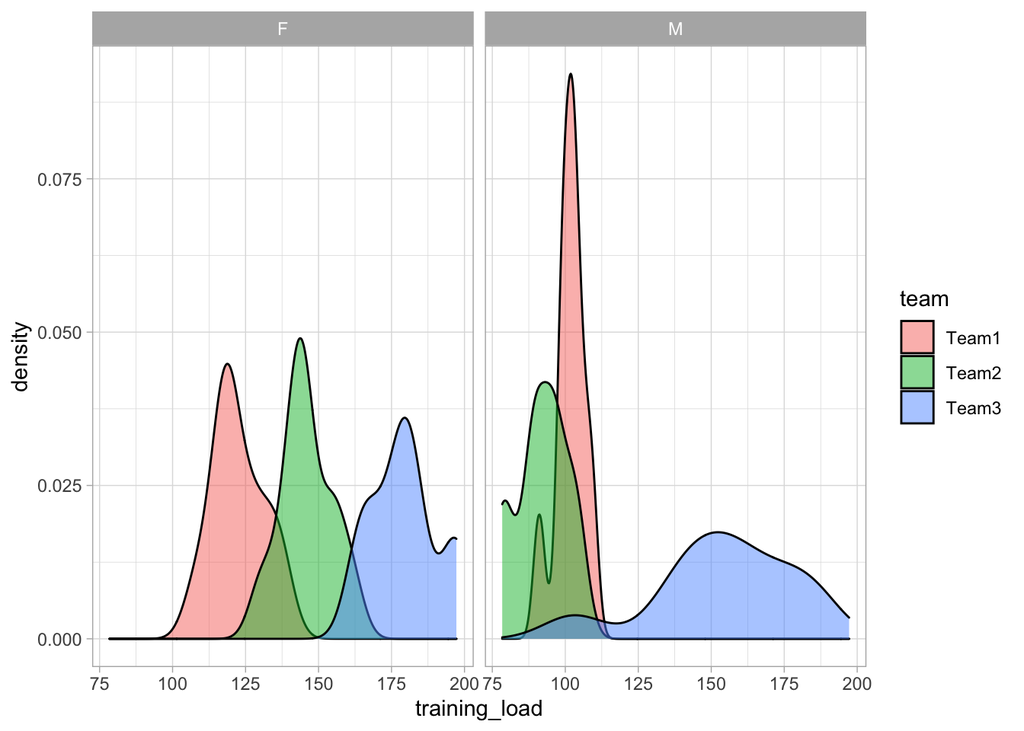

```r
## Plot
d %>%
  ggplot(aes(x = training_load, fill = team)) +
  geom_density(alpha = 0.5) +
  facet_wrap(~pos)
```

Construct the mixed model

```r
## Mixed Model
fit_lmer <- lmer(training_load ~ pos + (1 |team), data = d)
summary(fit_lmer)
```

```
## Linear mixed model fit by REML ['lmerMod']
## Formula: training_load ~ pos + (1 | team)
##    Data: d
##
## REML criterion at convergence: 491.3
##
## Scaled residuals:
##     Min      1Q  Median      3Q     Max
## -3.1888 -0.6177  0.0529  0.5721  2.3379
##
## Random effects:
##  Groups   Name        Variance Std.Dev.
##  team     (Intercept) 875.5    29.59
##  Residual             213.5    14.61
## Number of obs: 60, groups:  team, 3
##
## Fixed effects:
##             Estimate Std. Error t value
## (Intercept)  149.250     17.290   8.632
## posM         -33.272      3.773  -8.819
##
## Correlation of Fixed Effects:
##      (Intr)
## posM -0.109
```

```r
coef(fit_lmer)
```

```
## $team
##       (Intercept)      posM
## Team1    128.9875 -33.27234
## Team2    135.7802 -33.27234
## Team3    182.9832 -33.27234
##
## attr(,"class")
## [1] "coef.mer"
```

```r
fixef(fit_lmer)
```

```
## (Intercept)        posM
##   149.25030   -33.27234
```

```r
ranef(fit_lmer)
```

```
## $team
##       (Intercept)
## Team1   -20.26278
## Team2   -13.47009
## Team3    33.73287
##
## with conditional variances for "team"
```

```r
sigma(fit_lmer)
```

```
## [1] 14.6114
```

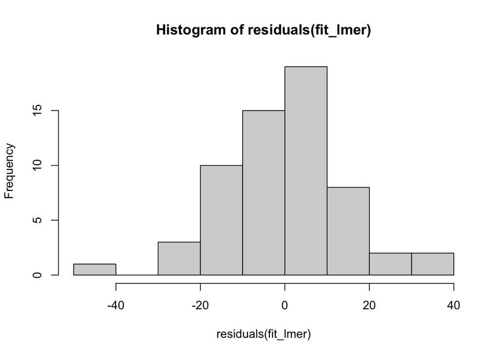

```r
hist(residuals(fit_lmer))
```

Write a mixed model function

```r
sim_func_lmer <- function(n_teams = 3,
                          n_positions = 2,
                          n_players = 10,
                          team1_fwd_avg = 130,
                          team1_fwd_sd = 15,
                          team1_mid_avg = 100,
                          team1_mid_sd = 5,
                          team2_fwd_avg = 150,
                          team2_fwd_sd = 20,
                          team2_mid_avg = 90,
                          team2_mid_sd = 10,
                          team3_fwd_avg = 180,
                          team3_fwd_sd = 15,
                          team3_mid_avg = 150,
                          team3_mid_sd = 15){

        ## Simulated data frame
        team <- rep(c("Team1","Team2", "Team3"), each = n_players * n_positions)
        pos <- c(rep(c("M", "F"), each = n_players), rep(c("M", "F"), each = n_players), rep(c("M", "F"), each = n_players))
        player_id <- as.factor(round(seq(from = 100, to = 300, length = length(team)), 0))

        d <- data.frame(team, pos, player_id)

        # simulate training loads
        training_load <- c(rnorm(n = n_players, mean = team1_mid_avg, sd = team1_mid_sd),
                   rnorm(n = n_players, mean = team1_fwd_avg, sd = team1_fwd_sd),
                   rnorm(n = n_players, mean = team2_mid_avg, sd = team2_mid_sd),
                   rnorm(n = n_players, mean = team2_fwd_avg, sd = team2_fwd_sd),
                   rnorm(n = n_players, mean = team3_mid_avg, sd = team3_mid_sd),
                   rnorm(n = n_players, mean = team3_fwd_avg, sd = team3_fwd_sd))

        ## construct the mixed model
  fit_lmer <- lmer(training_load ~ pos + (1 |team), data = d)
  summary(fit_lmer)
}
```

Try out the function

```r
sim_func_lmer()
```

```
## Linear mixed model fit by REML ['lmerMod']
## Formula: training_load ~ pos + (1 | team)
##    Data: d
##
## REML criterion at convergence: 509.8
##
## Scaled residuals:
##     Min      1Q  Median      3Q     Max
## -1.7379 -0.5789  0.0539  0.4813  3.2575
##
## Random effects:
##  Groups   Name        Variance Std.Dev.
##  team     (Intercept) 729.2    27.00
##  Residual             298.9    17.29
## Number of obs: 60, groups:  team, 3
##
## Fixed effects:
##             Estimate Std. Error t value
## (Intercept)  152.232     15.907   9.570
## posM         -37.933      4.464  -8.498
##
## Correlation of Fixed Effects:
##      (Intr)
## posM -0.140
```

Now use `replicate()` and create 1000 simulations of the model

```r
team_training_lmer <- replicate(n = 1000,
                  sim_func_lmer(),
                  simplify = FALSE)

## look at the first model in the list
team_training_lmer[[1]]$coefficient
```

```
##              Estimate Std. Error   t value
## (Intercept) 154.17554  16.260547  9.481571
## posM        -40.15081   4.789025 -8.383923
```

Coefficient Results

```r
lmer_coef <- matrix(NA, ncol = 5, nrow = length(team_training_lmer))
colnames(lmer_coef) <- c("intercept", "intercept_se", "posM", "posM_se", 'model_sigma')

for(i in 1:length(team_training_lmer)){

  lmer_coef[i, 1] <- team_training_lmer[[i]]$coefficients[1]
  lmer_coef[i, 2] <- team_training_lmer[[i]]$coefficients[3]
  lmer_coef[i, 3] <- team_training_lmer[[i]]$coefficients[2]
  lmer_coef[i, 4] <- team_training_lmer[[i]]$coefficients[4]
  lmer_coef[i, 5] <- team_training_lmer[[i]]$sigma

}

lmer_coef <- as.data.frame(lmer_coef)

head(lmer_coef)
```

```
##   intercept intercept_se      posM  posM_se model_sigma
## 1  154.1755     16.26055 -40.15081 4.789025    18.54781
## 2  153.2869     18.22671 -38.87669 4.185434    16.21012
## 3  155.2232     17.89597 -44.41296 3.758269    14.55571
## 4  160.4615     13.63313 -49.83162 4.863869    18.83768
## 5  150.5870     16.67754 -36.99185 4.239248    16.41854
## 6  153.5667     16.69399 -35.26878 4.384030    16.97928
```

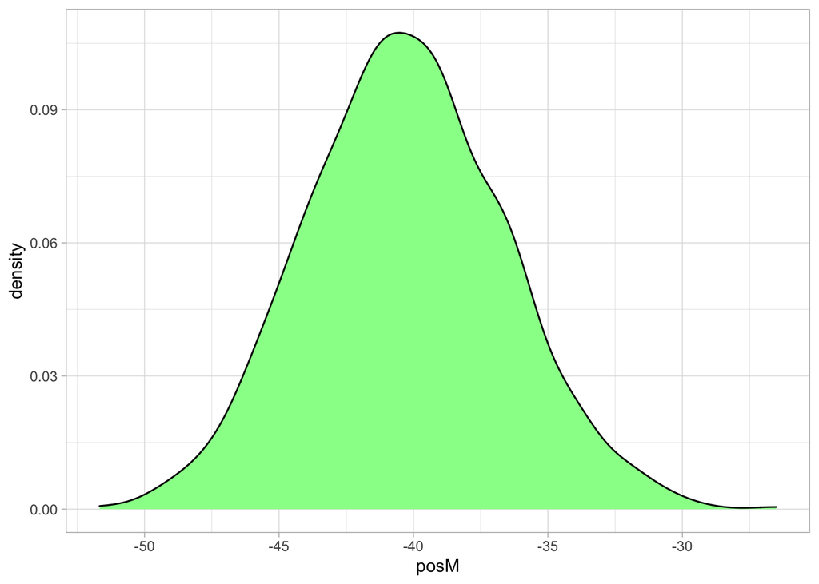

```r
## Plot the coefficient for position
lmer_coef %>%
  ggplot(aes(x = posM)) +
  geom_density(fill = "palegreen")
```

```r
## Summarize the coefficients and their standard errors for the simulations
lmer_coef %>%
  summarize(across(.cols = everything(),
                   ~mean(.x)))
```

```
##   intercept intercept_se      posM  posM_se model_sigma
## 1  153.4156     15.93105 -40.29287 4.081269    15.80669
```

```r
## compare to the original model
broom.mixed::tidy(fit_lmer)
```

```
## # A tibble: 4 × 6
##   effect   group    term            estimate std.error statistic
##   <chr>    <chr>    <chr>              <dbl>     <dbl>     <dbl>
## 1 fixed    <NA>     (Intercept)        149.      17.3       8.63
## 2 fixed    <NA>     posM               -33.3      3.77     -8.82
## 3 ran_pars team     sd__(Intercept)     29.6     NA        NA
## 4 ran_pars Residual sd__Observation     14.6     NA        NA
```

```r
sigma(fit_lmer)
```

```
## [1] 14.6114
```

Extract the random effects for the intercept and the residual for each of the simulated models

```r
ranef_sim <- matrix(NA, ncol = 2, nrow = length(team_training_lmer))
colnames(ranef_sim) <- c("intercept_sd", "residual_sd")

for(i in 1:length(team_training_lmer)){

  ranef_sim[i, 1] <- team_training_lmer[[i]]$varcor %>% as.data.frame() %>% select(sdcor) %>% slice(1) %>% pull(sdcor)
  ranef_sim[i, 2] <- team_training_lmer[[i]]$varcor %>% as.data.frame() %>% select(sdcor) %>% slice(2) %>% pull(sdcor)

}

ranef_sim <- as.data.frame(ranef_sim)
head(ranef_sim)
```

```
##   intercept_sd residual_sd
## 1     27.54658    18.54781
## 2     31.15064    16.21012
## 3     30.65306    14.55571
## 4     22.84953    18.83768
## 5     28.41592    16.41854
## 6     28.41194    16.97928
```

```r
## Summarize the results
ranef_sim %>%
  summarize(across(.cols = everything(),
                   ~mean(.x)))
```

```
##   intercept_sd residual_sd
## 1     27.12815    15.80669
```

```r
## Compare with the original model
VarCorr(fit_lmer)
```

```
##  Groups   Name        Std.Dev.
##  team     (Intercept) 29.589
##  Residual             14.611
```

## Mixed Model 2

Above was a pretty simple model, just to get our feet wet. Let’s create a more complicated model. Usually in sport and exercise science we have repeated measures of individuals. Often, researchers will set the individual players as random effects with the fixed effects being the component that the researcher is attempting to make an inference about.

In this example, we will set up a team of 12 players with three positions (4 players per position): Forward, Mid, Defender. The aim is to explore the training load differences between position groups while accounting for repeated observations of individuals (in this case, each player will have 20 training sessions). Similar to our first regression model, we will build a data frame of everything we need and then calculate the outcome variable (training load) with a regression model using parameters that we specify. To make this work, we will need to specific an intercept and slope for the position group and an intercept and slope for the individual players as well as a model sigma value. Once we’ve done that, we will fit a mixed model, write a function, and then create 1000 simulations.

```r
## Set up the data frame
n_pos <- 3
n_players <- 12
n_obs <- 20
players <- as.factor(round(seq(from = 100, to = 300, length = n_players), 0))


dat <- data.frame(
  player_id = rep(players, each = n_obs),
  pos = rep(c("Fwd", "Mid", "Def"), each = n_players/n_pos * n_obs),
  training_day = rep(1:n_obs, times = n_players)
)

dat %>%
  head()
```

```
##   player_id pos training_day
## 1       100 Fwd            1
## 2       100 Fwd            2
## 3       100 Fwd            3
## 4       100 Fwd            4
## 5       100 Fwd            5
## 6       100 Fwd            6
```

```r
## Create model parameters
# NOTE: Defender will be the intercept
set.seed(6687)
pos_intercept <- 150
posF_coef <- 170
posM_coef <- -70
individual_intercept <- 50
individual_slope <- 10
sigma <- 10
model_error <- rnorm(n = nrow(dat), mean = 0, sd = sigma)


## we will also create some individual player variance
individual_player_variance <- c()

for(i in players){

  individual_player_variance[i] <- rnorm(n = 1,
                  mean = runif(min = 2, max = 10, n = 1),
                  sd = runif(min = 2, max = 5, n = 1))

}

individual_player_variance <- rep(individual_player_variance, each = n_obs)

dat$training_load <- pos_intercept + posF_coef * (dat$pos == "Fwd") + posM_coef * (dat$pos == "Mid") + individual_intercept + individual_slope * individual_player_variance + model_error

dat %>%
  head()
```

```
##   player_id pos training_day training_load
## 1       100 Fwd            1      393.6911
## 2       100 Fwd            2      404.4232
## 3       100 Fwd            3      407.5023
## 4       100 Fwd            4      402.5702
## 5       100 Fwd            5      406.6927
## 6       100 Fwd            6      404.5130
```

Summary stats

```r
## Average training load by pos
dat %>%
  group_by(pos) %>%
  summarize(avg = mean(training_load),
            SD = sd(training_load))
```

```
## # A tibble: 3 × 3
##   pos     avg    SD
##   <chr> <dbl> <dbl>
## 1 Def    292.  42.6
## 2 Fwd    430.  30.5
## 3 Mid    200.  33.9
```

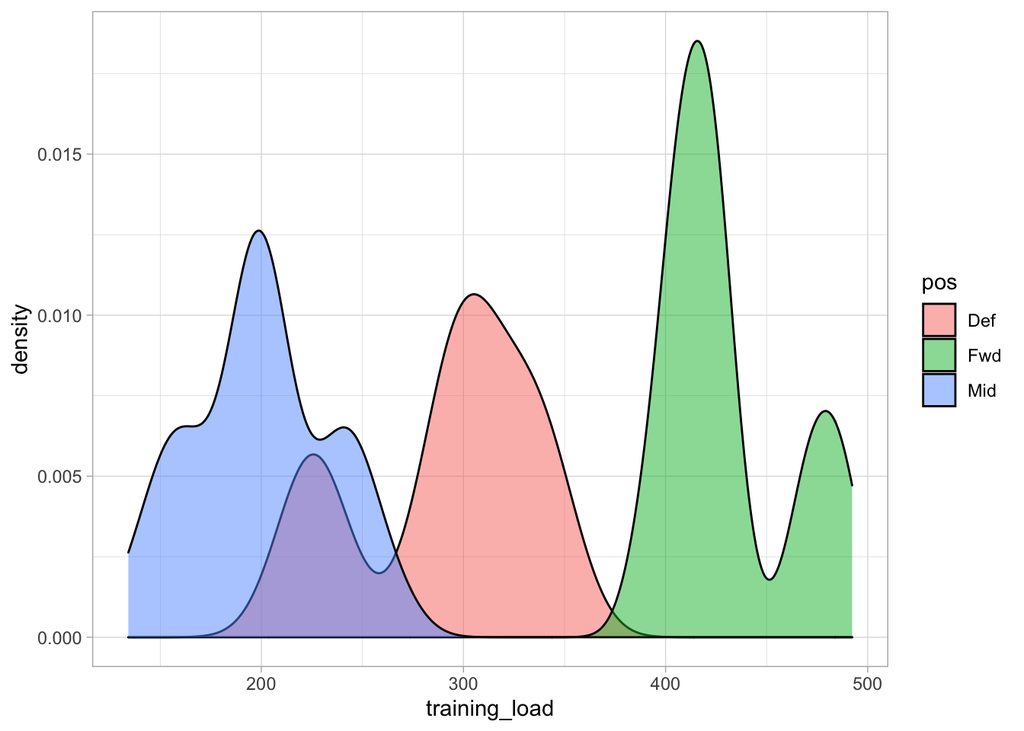

```r
## Plot
dat %>%
  ggplot(aes(x = training_load, fill = pos)) +
  geom_density(alpha = 0.5)
```

Construct the mixed model

```r
## Mixed Model
fit_lmer_pos <- lmer(training_load ~ pos + (1 | player_id), data = dat)
summary(fit_lmer_pos)
```

```
## Linear mixed model fit by REML ['lmerMod']
## Formula: training_load ~ pos + (1 | player_id)
##    Data: dat
##
## REML criterion at convergence: 1834.6
##
## Scaled residuals:
##      Min       1Q   Median       3Q      Max
## -2.50679 -0.60306  0.00082  0.62398  2.45004
##
## Random effects:
##  Groups    Name        Variance Std.Dev.
##  player_id (Intercept) 1576.4   39.70
##  Residual               102.5   10.12
## Number of obs: 240, groups:  player_id, 12
##
## Fixed effects:
##             Estimate Std. Error t value
## (Intercept)   291.86      19.88  14.678
## posFwd        138.20      28.12   4.915
## posMid        -91.80      28.12  -3.265
##
## Correlation of Fixed Effects:
##        (Intr) posFwd
## posFwd -0.707
## posMid -0.707  0.500
```

```r
coef(fit_lmer_pos)
```

```
## $player_id
##     (Intercept)   posFwd   posMid
## 100    264.6585 138.2049 -91.8014
## 118    340.3217 138.2049 -91.8014
## 136    284.8338 138.2049 -91.8014
## 155    277.6293 138.2049 -91.8014
## 173    247.1949 138.2049 -91.8014
## 191    337.8244 138.2049 -91.8014
## 209    291.8617 138.2049 -91.8014
## 227    290.5623 138.2049 -91.8014
## 245    338.2533 138.2049 -91.8014
## 264    226.0684 138.2049 -91.8014
## 282    298.1744 138.2049 -91.8014
## 300    304.9471 138.2049 -91.8014
##
## attr(,"class")
## [1] "coef.mer"
```

```r
fixef(fit_lmer_pos)
```

```
## (Intercept)      posFwd      posMid
##    291.8608    138.2049    -91.8014
```

```r
ranef(fit_lmer_pos)
```

```
## $player_id
##       (Intercept)
## 100 -2.720233e+01
## 118  4.846084e+01
## 136 -7.027017e+00
## 155 -1.423149e+01
## 173 -4.466592e+01
## 191  4.596360e+01
## 209  8.803661e-04
## 227 -1.298565e+00
## 245  4.639249e+01
## 264 -6.579240e+01
## 282  6.313612e+00
## 300  1.308629e+01
##
## with conditional variances for "player_id"
```

```r
sigma(fit_lmer_pos)
```

```
## [1] 10.12346
```

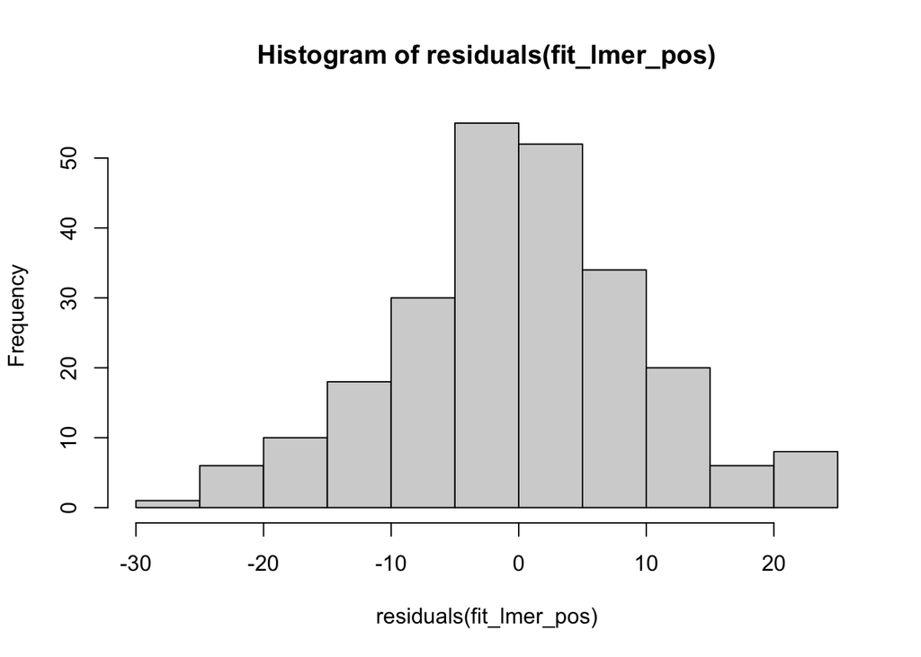

```r
hist(residuals(fit_lmer_pos))
```

Create a function for the simulation

```r
n_pos <- 3
n_players <- 12
n_obs <- 20


sim_func_lmer2 <- function(n_pos = 3,
                          n_players = 12,
                          n_obs = 20,
                          pos_intercept = 150,
                          posF_coef = 170,
                          posM_coef = -70,
                          individual_intercept = 50,
                          individual_slope = 10,
                          sigma = 10){

  players <- as.factor(round(seq(from = 100, to = 300, length = n_players), 0))

  dat <- data.frame(
  player_id = rep(players, each = n_obs),
  pos = rep(c("Fwd", "Mid", "Def"), each = n_players/n_pos * n_obs),
  training_day = rep(1:n_obs, times = n_players)
  )

  model_error <- rnorm(n = nrow(dat), mean = 0, sd = sigma)

  individual_player_variance <- c()

  for(i in players){

    individual_player_variance[i] <- rnorm(n = 1,
                  mean = runif(min = 2, max = 10, n = 1),
                  sd = runif(min = 2, max = 5, n = 1))
    }

  individual_player_variance <- rep(individual_player_variance, each = n_obs)

  dat$training_load <- pos_intercept + posF_coef * (dat$pos == "Fwd") + posM_coef * (dat$pos == "Mid") + individual_intercept + individual_slope * individual_player_variance + model_error

  fit_lmer_pos <- lmer(training_load ~ pos + (1 | player_id), data = dat)
  summary(fit_lmer_pos)
}
```

Try out the function

```r
sim_func_lmer2()
```

```
## Linear mixed model fit by REML ['lmerMod']
## Formula: training_load ~ pos + (1 | player_id)
##    Data: dat
##
## REML criterion at convergence: 1812.3
##
## Scaled residuals:
##      Min       1Q   Median       3Q      Max
## -2.56067 -0.68364 -0.06087  0.65396  2.96943
##
## Random effects:
##  Groups    Name        Variance Std.Dev.
##  player_id (Intercept) 412.36   20.307
##  Residual               97.96    9.897
## Number of obs: 240, groups:  player_id, 12
##
## Fixed effects:
##             Estimate Std. Error t value
## (Intercept)   281.29      10.21  27.542
## posFwd        131.06      14.44   9.074
## posMid       -118.52      14.44  -8.206
##
## Correlation of Fixed Effects:
##        (Intr) posFwd
## posFwd -0.707
## posMid -0.707  0.500
```

Now use `replicate()` and create 1000 simulations of the model

```r
player_training_lmer <- replicate(n = 1000,
                  sim_func_lmer2(),
                  simplify = FALSE)

## look at the first model in the list
player_training_lmer[[1]]$coefficient
```

```
##              Estimate Std. Error   t value
## (Intercept) 245.70651   29.02827  8.464388
## posFwd      165.64768   41.05217  4.035053
## posMid      -76.62128   41.05217 -1.866437
```

Coefficient Results

```r
lmer_player_coef <- matrix(NA, ncol = 7, nrow = length(player_training_lmer))
colnames(lmer_player_coef) <- c("intercept", "intercept_se","posFwd", "posFwd_se", "posMid", "posMid_se", 'model_sigma')

for(i in 1:length(player_training_lmer)){

  lmer_player_coef[i, 1] <- player_training_lmer[[i]]$coefficients[1]
  lmer_player_coef[i, 2] <- player_training_lmer[[i]]$coefficients[4]
  lmer_player_coef[i, 3] <- player_training_lmer[[i]]$coefficients[2]
  lmer_player_coef[i, 4] <- player_training_lmer[[i]]$coefficients[5]
  lmer_player_coef[i, 5] <- player_training_lmer[[i]]$coefficients[3]
  lmer_player_coef[i, 6] <- player_training_lmer[[i]]$coefficients[6]
  lmer_player_coef[i, 7] <- player_training_lmer[[i]]$sigma

}

lmer_player_coef <- as.data.frame(lmer_player_coef)

head(lmer_player_coef)
```

```
##   intercept intercept_se   posFwd posFwd_se    posMid posMid_se model_sigma
## 1  245.7065     29.02827 165.6477  41.05217 -76.62128  41.05217    9.721098
## 2  225.3849     25.17196 216.6547  35.59852 -23.30451  35.59852    9.901295
## 3  263.6954     24.92826 159.5845  35.25389 -63.05434  35.25389    8.876656
## 4  232.2708     18.96796 161.2350  26.82474 -20.31907  26.82474   10.390009
## 5  249.9661     14.85257 204.7150  21.00471 -68.50798  21.00471    9.199910
## 6  260.7439     28.26872 103.4908  39.97800 -35.03053  39.97800    9.781426
```

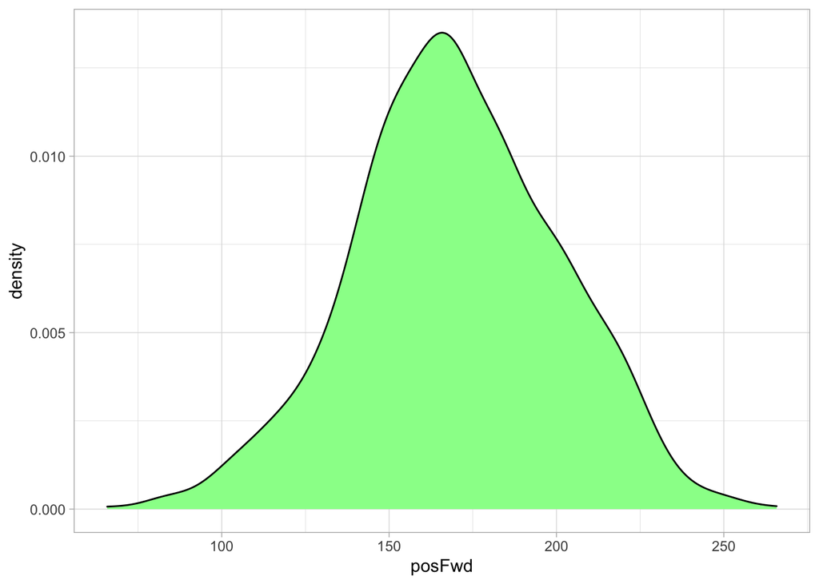

```r
## Plot the coefficient for position
lmer_player_coef %>%
  ggplot(aes(x = posFwd)) +
  geom_density(fill = "palegreen")
```

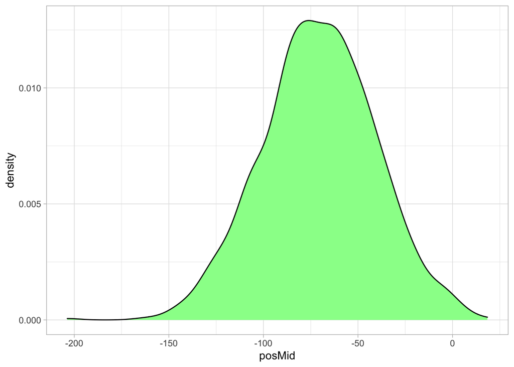

```r
lmer_player_coef %>%
  ggplot(aes(x = posMid)) +
  geom_density(fill = "palegreen")
```

```r
## Summarize the coefficients and their standard errors for the simulations
lmer_player_coef %>%
  summarize(across(.cols = everything(),
                   ~mean(.x)))
```

```
##   intercept intercept_se   posFwd posFwd_se    posMid posMid_se model_sigma
## 1  260.5939     20.97634 169.8577  29.66502 -70.61672  29.66502    9.991778
```

```r
## compare to the original model
broom.mixed::tidy(fit_lmer_pos)
```

```
## # A tibble: 5 × 6
##   effect   group     term            estimate std.error statistic
##   <chr>    <chr>     <chr>              <dbl>     <dbl>     <dbl>
## 1 fixed    <NA>      (Intercept)        292.       19.9     14.7
## 2 fixed    <NA>      posFwd             138.       28.1      4.91
## 3 fixed    <NA>      posMid             -91.8      28.1     -3.26
## 4 ran_pars player_id sd__(Intercept)     39.7      NA       NA
## 5 ran_pars Residual  sd__Observation     10.1      NA       NA
```

```r
sigma(fit_lmer_pos)
```

```
## [1] 10.12346
```

Extract the random effects for the intercept and the residual for each of the simulated models

```r
ranef_sim_player <- matrix(NA, ncol = 2, nrow = length(player_training_lmer))
colnames(ranef_sim_player) <- c("player_sd", "residual_sd")

for(i in 1:length(player_training_lmer)){

  ranef_sim_player[i, 1] <- player_training_lmer[[i]]$varcor %>% as.data.frame() %>% select(sdcor) %>% slice(1) %>% pull(sdcor)
  ranef_sim_player[i, 2] <- player_training_lmer[[i]]$varcor %>% as.data.frame() %>% select(sdcor) %>% slice(2) %>% pull(sdcor)

}

ranef_sim_player <- as.data.frame(ranef_sim_player)
head(ranef_sim_player)
```

```
##   player_sd residual_sd
## 1  58.01583    9.721098
## 2  50.29520    9.901295
## 3  49.81700    8.876656
## 4  37.86471   10.390009
## 5  29.63382    9.199910
## 6  56.49511    9.781426
```

```r
## Summarize the results
ranef_sim_player %>%
  summarize(across(.cols = everything(),
                   ~mean(.x)))
```

```
##   player_sd residual_sd
## 1  41.88908    9.991778
```

```r
## Compare with the original model
VarCorr(fit_lmer_pos)
```

```
##  Groups    Name        Std.Dev.
##  player_id (Intercept) 39.704
##  Residual              10.123
```

## Wrapping Up

Mixed models can get really complicated and have a lot of layers to them. For example, we could make this a multivariable model with independent variables that have some level of correlation with each other. We could also add some level of autocorrelation for each player’s observations. There are also a number of different ways that you can construct these types of simulations. The two approaches used here are just dipping their toes in. Perhaps in future articles I’ll put together code for more complex mixed models.